# YF vaccination coverage model

Mirava Yuson

2026-08-19

## Overview

This code generates a model for estimating sublevel vaccination coverage against vaccine-preventable diseases. For this manuscript, it was used to estimate district-level vaccination coverage against yellow fever in Ghana from 2000 to 2025. The steps for producing these estimates are as follows.

## Setup: display code and output

## Setup: R packages

```r
library(tidyr)
library(ggplot2)
library(dplyr)
library(scales)
library(sf)
library(readr)
library(stringr)
library(grid) #map cropping
library(ggrepel) #map labelling
```

## Setup: Replace all missing values with 0

```r
clamp01 <- function(x) { x[is.na(x)] <- 0; pmin(pmax(x, 0), 1) }
```

## Step 1: Produce model

This code uses baseline coverage from 2000 to estimate district-level YF vaccination coverage in Ghana by producing a stock-and-flow model where allocated proportions of infant and non-infant populations are transfered to vaccinated infant and non-infant compartments year to year following routine immunization (infants only) or supplementary immunization activities (infants and non-infants). The cumulative number of vaccinated infants and non-infants is therefore divided by the total population per district in each year to calculate vaccination coverage. Previously vaccinated individuals are presumed to be excluded from further vaccination, and vaccination is presumed to confer lifelong protection.

The model-estimated coverages are currently being used as covariates for risk mapping.

```r
run_model_one_district <- function(df) {

  df <- df %>%
    filter(year >= 2000) %>%
    mutate(year = as.numeric(year)) %>%
    arrange(year)

  #Stop running if not enough data
  if (nrow(df) < 2) {
    return(df[0, ])
  }

  #Check required/missing columns
  required_cols <- c("year","infants","total_pop","shearer_opt","routine","supplementary")
  missing_cols <- setdiff(required_cols, names(df))
  if (length(missing_cols) > 0) {
    stop("Missing required columns for district ", unique(df$district),
         ": ", paste(missing_cols, collapse = ", "))
  }

  #Turn columns into numeric format
  num_cols <- c("infants","total_pop","shearer_opt","routine","supplementary")
  df[num_cols] <- lapply(df[num_cols], function(x) as.numeric(as.character(x)))

  #Error out any N/As
  if (anyNA(df$infants) || anyNA(df$total_pop)) {
    bad <- which(is.na(df$infants) | is.na(df$total_pop))[1]
    stop("NA in infants/total_pop at district ", unique(df$district),
         ", year ", df$year[bad], ". Fix the CSV.")
  }
  if (any(df$infants < 0, na.rm = TRUE) || any(df$total_pop < 0, na.rm = TRUE)) {
    stop("Negative infants or total_pop found in district ", unique(df$district), ". Fix the CSV.")
  }
  if (any(df$infants > df$total_pop, na.rm = TRUE)) {
    bad <- which(df$infants > df$total_pop)[1]
    stop("infants > total_pop at district ", unique(df$district),
         ", year ", df$year[bad], ". Fix the CSV.")
  }

  #Ensure that coverage is between 0 and 1; N/A becomes 0
  df$shearer_opt    <- clamp01(df$shearer_opt)
  df$routine        <- clamp01(df$routine)
  df$supplementary  <- clamp01(df$supplementary)

  #Allocate storage columns
  df <- df %>%
    mutate(
      #Number of people per state
      U_inf = NA_real_, V_inf = NA_real_,
      U_noninf = NA_real_, V_noninf = NA_real_,
      #Totals
      vaccinated_total = NA_real_,
      Coverage_stock = NA_real_,
      RI_flow = NA_real_,
      #Flows (each year's results)
      SIA_flow_inf = NA_real_,
      SIA_flow_noninf = NA_real_,
      SIA_flow = NA_real_,
      Total_flow = NA_real_
    )

  #Baseline year (t = 1)
  t1 <- 1
  infants1    <- df$infants[t1]
  total_pop1  <- df$total_pop[t1]
  noninf_pop1 <- total_pop1 - infants1

  U_inf_prev    <- infants1
  V_inf_prev    <- 0
  V_noninf_prev <- df$shearer_opt[t1] * noninf_pop1
  U_noninf_prev <- noninf_pop1 - V_noninf_prev

  df$U_inf[t1]    <- U_inf_prev
  df$V_inf[t1]    <- V_inf_prev
  df$U_noninf[t1] <- U_noninf_prev
  df$V_noninf[t1] <- V_noninf_prev

  df$vaccinated_total[t1] <- V_inf_prev + V_noninf_prev
  df$Coverage_stock[t1]   <- df$vaccinated_total[t1] / total_pop1

  df$RI_flow[t1]         <- 0
  df$SIA_flow_inf[t1]    <- 0
  df$SIA_flow_noninf[t1] <- 0
  df$SIA_flow[t1]        <- 0
  df$Total_flow[t1]      <- 0

  #Simulation loop
  for (t in 2:nrow(df)) {

    infants    <- df$infants[t]
    total_pop  <- df$total_pop[t]
    noninf_pop <- total_pop - infants

    r <- df$routine[t]
    s <- df$supplementary[t]

    #1) New infants enter
    U_inf <- infants
    V_inf <- 0

    #2) RI among infants only
    RI <- r * U_inf
    U_inf_after_RI <- U_inf - RI
    V_inf_after_RI <- V_inf + RI

    #3) Age last year's infants into non-infants
    U_noninf_temp <- U_noninf_prev + U_inf_prev
    V_noninf_temp <- V_noninf_prev + V_inf_prev

    #4) SIA applied to unvaccinated (infants + noninfants) only
    total_unvax_before_SIA <- max(U_inf_after_RI + U_noninf_temp, 0)

    SIA_total <- min(s * total_unvax_before_SIA, total_unvax_before_SIA)

    if (total_unvax_before_SIA > 0) {
      SIA_inf    <- SIA_total * (U_inf_after_RI / total_unvax_before_SIA)
      SIA_noninf <- SIA_total - SIA_inf
    } else {
      SIA_inf <- 0
      SIA_noninf <- 0
    }

    #Apply transfers (moving people from unvaccinated to vaccinated)
    U_inf_final    <- max(U_inf_after_RI - SIA_inf, 0)
    V_inf_final    <- max(V_inf_after_RI + SIA_inf, 0)

    U_noninf_final <- max(U_noninf_temp - SIA_noninf, 0)
    V_noninf_final <- max(V_noninf_temp + SIA_noninf, 0)

    #5) Mass balance via proportional rescaling to match total population
    inf_total <- U_inf_final + V_inf_final
    if (inf_total > 0) {
      scale_inf <- infants / inf_total
      U_inf_final <- U_inf_final * scale_inf
      V_inf_final <- V_inf_final * scale_inf
    } else {
      U_inf_final <- infants
      V_inf_final <- 0
    }

    noninf_total <- U_noninf_final + V_noninf_final
    if (noninf_total > 0) {
      scale_noninf <- noninf_pop / noninf_total
      U_noninf_final <- U_noninf_final * scale_noninf
      V_noninf_final <- V_noninf_final * scale_noninf
    } else {
      U_noninf_final <- noninf_pop
      V_noninf_final <- 0
    }

    #Store each year's results
    df$U_inf[t]    <- U_inf_final
    df$V_inf[t]    <- V_inf_final
    df$U_noninf[t] <- U_noninf_final
    df$V_noninf[t] <- V_noninf_final

    df$vaccinated_total[t] <- V_inf_final + V_noninf_final
    df$Coverage_stock[t]   <- if (total_pop > 0) df$vaccinated_total[t] / total_pop else NA_real_

    #Store flows
    df$RI_flow[t]         <- RI
    df$SIA_flow_inf[t]    <- SIA_inf
    df$SIA_flow_noninf[t] <- SIA_noninf
    df$SIA_flow[t]        <- SIA_total
    df$Total_flow[t]      <- RI + SIA_total

    #Carry forward (How many vaccinations happened this year?)
    U_inf_prev    <- U_inf_final
    V_inf_prev    <- V_inf_final
    U_noninf_prev <- U_noninf_final
    V_noninf_prev <- V_noninf_final
  }

  #Check that total number of infants/non-infants makes sense
  stopifnot(all(abs((df$U_inf + df$V_inf) - df$infants) < 1e-6))
  stopifnot(all(abs((df$U_noninf + df$V_noninf) - (df$total_pop - df$infants)) < 1e-6))

  df
}
```

## Step 2: run model for all 261 Ghana districts

```r
raw <- read_csv("optimistic1970.csv")
results <- raw %>%
  group_by(district) %>%
  group_modify(~ run_model_one_district(.x)) %>%
  ungroup()
```

## Step 3: Save model-estimated coverage values (“Coverage_stock” column) to .csv for risk mapping

```r
write.csv(
  results %>%
    select(district, year, Coverage_stock),
  "coverage_by_district_year_opt2000.csv",
  row.names = FALSE
)
```

## Additional: Organize data sets for geographic mapping of 2005 - 2025 data only

```r
#Shapefile (.dbf and .shx files should be in same folder)
districts_sf <- st_read(
  "261_Districts.shp",
  quiet = FALSE
)
#Coverage data
cov <- read_csv(
  "coverage_by_district_year_opt2000.csv",
  col_types = cols(
    district = col_character(),
    year = col_integer(),
    Coverage_stock = col_double()
  )
) %>%
  filter(year >= 2005, year <= 2025)

#Clean district names to match both datasets
clean_name <- function(x) {
  x %>%
    str_to_lower() %>%
    str_trim() %>%
    str_replace_all("[[:punct:]]", " ") %>%
    str_replace_all("\\s+", " ")
}

districts_sf2 <- districts_sf %>%
  mutate(
    district_key = clean_name(District)  # <-- replace DIST_NAME_FIELD
  )

cov2 <- cov %>%
  mutate(
    district_key = clean_name(district)
  )

#Check if district names match
unmatched_cov <- cov2 %>%
  anti_join(districts_sf2 %>% st_drop_geometry() %>% select(district_key),
            by = "district_key") %>%
  distinct(district) %>%
  arrange(district)

unmatched_shp <- districts_sf2 %>%
  st_drop_geometry() %>%
  anti_join(cov2 %>% select(district_key) %>% distinct(),
            by = "district_key") %>%
  distinct(district_key)

unmatched_cov
```

```
## # A tibble: 0 × 1
## # ℹ 1 variable: district <chr>
```

```r
unmatched_shp
```

```
##   district_key
## 1         <NA>
```

```r
#Join geometry x coverage (missing years become N/A)
years <- 2005:2025

#Full grid: every district in shapefile per year
grid <- expand_grid(
  district_key = districts_sf2 %>% st_drop_geometry() %>% pull(district_key) %>% unique(),
  year = years
)

cov_full <- grid %>%
  left_join(cov2 %>% select(district_key, year, Coverage_stock),
            by = c("district_key", "year"))

map_data <- districts_sf2 %>%
  left_join(cov_full, by = "district_key")
```

## Additional: Map vaccination coverage in Ghana from 2005 to 2025.

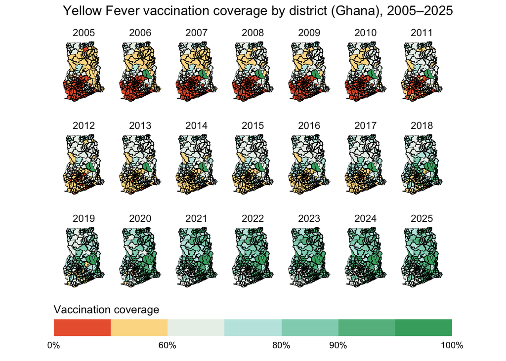

```r
p <- ggplot(map_data) +
  geom_sf(aes(fill = Coverage_stock),
          color = "black",
          linewidth = 0.10) +
  coord_sf(expand = FALSE) +
  facet_wrap(~ year, ncol = 7) +
  scale_fill_stepsn(
    colours = c("#8c1d18", "#d7301f", "#fc8d59", "#FFD166",
                "#e5f5f9", "#99d8c9", "#2ca25f"),
    breaks  = c(0, 0.5, 0.6, 0.7, 0.8, 0.9, 0.95, 1.0),
    limits  = c(0, 1),
    labels = function(x) {
      labs <- percent(x, accuracy = 1)
      show <- x %in% c(0, 0.6, 0.8, 0.9, 1.0)  # key thresholds
      labs[!show] <- ""
      labs
    },
    na.value = "grey85",
    name = "Vaccination coverage"
  ) +
  labs(
    title = "Yellow Fever vaccination coverage by district (Ghana), 2005–2025" #,
    #subtitle = "(Optimistic)"
  ) +
  theme_minimal(base_size = 11) +
  theme(
    axis.text = element_blank(),
    axis.ticks = element_blank(),
    panel.grid = element_blank(),
    strip.text = element_text(size = 10),
    legend.position = "bottom",
    legend.key.width = unit(30, "pt"),
    legend.title = element_text(margin = margin(b = 5)),
    legend.text = element_text(size = 9)
  ) +
  theme(
  panel.spacing = unit(1, "lines")
) +
  guides(
    fill = guide_colorsteps(
      title.position = "top",
      label.position = "bottom",
      barwidth = unit(14, "cm"),
      barheight = unit(0.6, "cm")
    )
  )

p
```

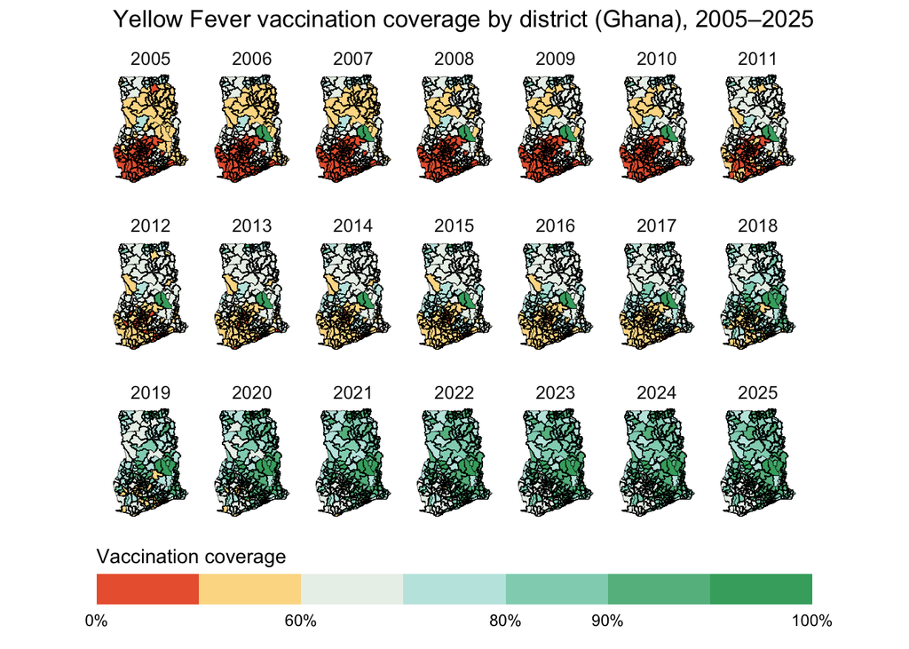

```r
print(p)
```

```r
ggsave(
  filename = "ghana_coverage_facets_2005_2025opt_landscape.png",
  plot = p,
  width = 24,
  height = 14,
  dpi = 300
)
```